# Class JScrollPane

java.lang.Object

java.awt.Component

java.awt.Container

javax.swing.JComponent

javax.swing.JScrollPane

**All Implemented Interfaces:**

`ImageObserver`, `MenuContainer`, `Serializable`, `Accessible`, `ScrollPaneConstants`

```java
@JavaBean(defaultProperty="UI", description="A specialized container that manages a viewport, optional scrollbars and headers") public class JScrollPane extends JComponent implements ScrollPaneConstants, Accessible
```

Provides a scrollable view of a lightweight component. A `JScrollPane` manages a viewport, optional vertical and horizontal scroll bars, and optional row and column heading viewports. You can find task-oriented documentation of `JScrollPane` in [How to Use Scroll Panes](https://docs.oracle.com/javase/tutorial/uiswing/components/scrollpane.html), a section in *The Java Tutorial*. Note that `JScrollPane` does not support heavyweight components.

**Example:**

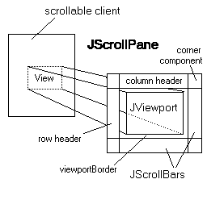

The `JViewport` provides a window, or "viewport" onto a data source -- for example, a text file. That data source is the "scrollable client" (aka data model) displayed by the `JViewport` view. A `JScrollPane` basically consists of `JScrollBar`s, a `JViewport`, and the wiring between them, as shown in the diagram at right.

In addition to the scroll bars and viewport, a `JScrollPane` can have a column header and a row header. Each of these is a `JViewport` object that you specify with `setRowHeaderView`, and `setColumnHeaderView`. The column header viewport automatically scrolls left and right, tracking the left-right scrolling of the main viewport. (It never scrolls vertically, however.) The row header acts in a similar fashion.

Where two scroll bars meet, the row header meets the column header, or a scroll bar meets one of the headers, both components stop short of the corner, leaving a rectangular space which is, by default, empty. These spaces can potentially exist in any number of the four corners. In the previous diagram, the top right space is present and identified by the label "corner component".

Any number of these empty spaces can be replaced by using the `setCorner` method to add a component to a particular corner. (Note: The same component cannot be added to multiple corners.) This is useful if there's some extra decoration or function you'd like to add to the scroll pane. The size of each corner component is entirely determined by the size of the headers and/or scroll bars that surround it.

A corner component will only be visible if there is an empty space in that corner for it to exist in. For example, consider a component set into the top right corner of a scroll pane with a column header. If the scroll pane's vertical scrollbar is not present, perhaps because the view component hasn't grown large enough to require it, then the corner component will not be shown (since there is no empty space in that corner created by the meeting of the header and vertical scroll bar). Forcing the scroll bar to always be shown, using `setVerticalScrollBarPolicy(VERTICAL_SCROLLBAR_ALWAYS)`, will ensure that the space for the corner component always exists.

To add a border around the main viewport, you can use `setViewportBorder`. (Of course, you can also add a border around the whole scroll pane using `setBorder`.)

A common operation to want to do is to set the background color that will be used if the main viewport view is smaller than the viewport, or is not opaque. This can be accomplished by setting the background color of the viewport, via `scrollPane.getViewport().setBackground()`. The reason for setting the color of the viewport and not the scrollpane is that by default `JViewport` is opaque which, among other things, means it will completely fill in its background using its background color. Therefore when `JScrollPane` draws its background the viewport will usually draw over it.

By default `JScrollPane` uses `ScrollPaneLayout` to handle the layout of its child Components. `ScrollPaneLayout` determines the size to make the viewport view in one of two ways:

1. If the view implements `Scrollable` a combination of `getPreferredScrollableViewportSize`, `getScrollableTracksViewportWidth` and `getScrollableTracksViewportHeight`is used, otherwise
2. `getPreferredSize` is used.

**Warning:** Swing is not thread safe. For more information see Swing's Threading Policy.

**Warning:** Serialized objects of this class will not be compatible with future Swing releases. The current serialization support is appropriate for short term storage or RMI between applications running the same version of Swing. As of 1.4, support for long term storage of all JavaBeans has been added to the `java.beans` package. Please see `XMLEncoder`.

**Since:**

1.2

**See Also:**

- `JScrollBar`
- `JViewport`
- `ScrollPaneLayout`
- `Scrollable`
- `Component.getPreferredSize()`
- `setViewportView(java.awt.Component)`
- `setRowHeaderView(java.awt.Component)`
- `setColumnHeaderView(java.awt.Component)`
- `setCorner(java.lang.String, java.awt.Component)`
- `setViewportBorder(javax.swing.border.Border)`

## Nested Class Summary

| Modifier and Type | Class | Description |
| --- | --- | --- |
| `protected class` | `JScrollPane.AccessibleJScrollPane` | This class implements accessibility support for the `JScrollPane` class. |
| `protected class` | `JScrollPane.ScrollBar` | By default `JScrollPane` creates scrollbars that are instances of this class. |

## Nested classes/interfaces declared in class javax.swing.JComponent

`JComponent.AccessibleJComponent`

## Nested classes/interfaces declared in class java.awt.Container

`Container.AccessibleAWTContainer`

## Nested classes/interfaces declared in class java.awt.Component

`Component.AccessibleAWTComponent, Component.BaselineResizeBehavior, Component.BltBufferStrategy, Component.FlipBufferStrategy`

## Field Summary

| Modifier and Type | Field | Description |
| --- | --- | --- |
| `protected JViewport` | `columnHeader` | The column header child. |
| `protected JScrollBar` | `horizontalScrollBar` | The scrollpane's horizontal scrollbar child. |
| `protected int` | `horizontalScrollBarPolicy` | The display policy for the horizontal scrollbar. |
| `protected Component` | `lowerLeft` | The component to display in the lower left corner. |
| `protected Component` | `lowerRight` | The component to display in the lower right corner. |
| `protected JViewport` | `rowHeader` | The row header child. |
| `protected Component` | `upperLeft` | The component to display in the upper left corner. |
| `protected Component` | `upperRight` | The component to display in the upper right corner. |
| `protected JScrollBar` | `verticalScrollBar` | The scrollpane's vertical scrollbar child. |
| `protected int` | `verticalScrollBarPolicy` | The display policy for the vertical scrollbar. |
| `protected JViewport` | `viewport` | The scrollpane's viewport child. |

### Fields declared in class javax.swing.JComponent

`listenerList, TOOL_TIP_TEXT_KEY, ui, UNDEFINED_CONDITION, WHEN_ANCESTOR_OF_FOCUSED_COMPONENT, WHEN_FOCUSED, WHEN_IN_FOCUSED_WINDOW`

### Fields declared in class java.awt.Component

`accessibleContext, BOTTOM_ALIGNMENT, CENTER_ALIGNMENT, LEFT_ALIGNMENT, RIGHT_ALIGNMENT, TOP_ALIGNMENT`

### Fields declared in interface java.awt.image.ImageObserver

`ABORT, ALLBITS, ERROR, FRAMEBITS, HEIGHT, PROPERTIES, SOMEBITS, WIDTH`

### Fields declared in interface javax.swing.ScrollPaneConstants

`COLUMN_HEADER, HORIZONTAL_SCROLLBAR, HORIZONTAL_SCROLLBAR_ALWAYS, HORIZONTAL_SCROLLBAR_AS_NEEDED, HORIZONTAL_SCROLLBAR_NEVER, HORIZONTAL_SCROLLBAR_POLICY, LOWER_LEADING_CORNER, LOWER_LEFT_CORNER, LOWER_RIGHT_CORNER, LOWER_TRAILING_CORNER, ROW_HEADER, UPPER_LEADING_CORNER, UPPER_LEFT_CORNER, UPPER_RIGHT_CORNER, UPPER_TRAILING_CORNER, VERTICAL_SCROLLBAR, VERTICAL_SCROLLBAR_ALWAYS, VERTICAL_SCROLLBAR_AS_NEEDED, VERTICAL_SCROLLBAR_NEVER, VERTICAL_SCROLLBAR_POLICY, VIEWPORT`

## Constructor Summary

| Constructor | Description |
| --- | --- |
| `JScrollPane()` | Creates an empty (no viewport view) `JScrollPane` where both horizontal and vertical scrollbars appear when needed. |
| JScrollPane(int vsbPolicy, int hsbPolicy) | Creates an empty (no viewport view) `JScrollPane` with specified scrollbar policies. |
| `JScrollPane(Component view)` | Creates a `JScrollPane` that displays the contents of the specified component, where both horizontal and vertical scrollbars appear whenever the component's contents are larger than the view. |
| JScrollPane(Component view, int vsbPolicy, int hsbPolicy) | Creates a `JScrollPane` that displays the view component in a viewport whose view position can be controlled with a pair of scrollbars. |

## Method Summary

| Modifier and Type | Method | Description |
| --- | --- | --- |
| `JScrollBar` | `createHorizontalScrollBar()` | Returns a `JScrollPane.ScrollBar` by default. |
| `JScrollBar` | `createVerticalScrollBar()` | Returns a `JScrollPane.ScrollBar` by default. |
| `protected JViewport` | `createViewport()` | Returns a new `JViewport` by default. |
| `AccessibleContext` | `getAccessibleContext()` | Gets the AccessibleContext associated with this JScrollPane. |
| `JViewport` | `getColumnHeader()` | Returns the column header. |
| `Component` | `getCorner(String key)` | Returns the component at the specified corner. |
| `JScrollBar` | `getHorizontalScrollBar()` | Returns the horizontal scroll bar that controls the viewport's horizontal view position. |
| `int` | `getHorizontalScrollBarPolicy()` | Returns the horizontal scroll bar policy value. |
| `JViewport` | `getRowHeader()` | Returns the row header. |
| `ScrollPaneUI` | `getUI()` | Returns the look and feel (L&F) object that renders this component. |
| `String` | `getUIClassID()` | Returns the suffix used to construct the name of the L&F class used to render this component. |
| `JScrollBar` | `getVerticalScrollBar()` | Returns the vertical scroll bar that controls the viewports vertical view position. |
| `int` | `getVerticalScrollBarPolicy()` | Returns the vertical scroll bar policy value. |
| `JViewport` | `getViewport()` | Returns the current `JViewport`. |
| `Border` | `getViewportBorder()` | Returns the `Border` object that surrounds the viewport. |
| `Rectangle` | `getViewportBorderBounds()` | Returns the bounds of the viewport's border. |
| `boolean` | `isValidateRoot()` | Overridden to return true so that any calls to `revalidate` on any descendants of this `JScrollPane` will cause the entire tree beginning with this `JScrollPane` to be validated. |
| `boolean` | `isWheelScrollingEnabled()` | Indicates whether or not scrolling will take place in response to the mouse wheel. |
| `protected String` | `paramString()` | Returns a string representation of this `JScrollPane`. |
| `void` | `setColumnHeader(JViewport columnHeader)` | Removes the old columnHeader, if it exists; if the new columnHeader isn't `null`, syncs the x coordinate of its viewPosition with the viewport (if there is one) and then adds it to the scroll pane. |
| `void` | `setColumnHeaderView(Component view)` | Creates a column-header viewport if necessary, sets its view, and then adds the column-header viewport to the scrollpane. |
| `void` | `setComponentOrientation(ComponentOrientation co)` | Sets the orientation for the vertical and horizontal scrollbars as determined by the `ComponentOrientation` argument. |
| `void` | setCorner(String key, Component corner) | Adds a child that will appear in one of the scroll panes corners, if there's room. |
| `void` | `setHorizontalScrollBar(JScrollBar horizontalScrollBar)` | Adds the scrollbar that controls the viewport's horizontal view position to the scrollpane. |
| `void` | `setHorizontalScrollBarPolicy(int policy)` | Determines when the horizontal scrollbar appears in the scrollpane. |
| `void` | `setLayout(LayoutManager layout)` | Sets the layout manager for this `JScrollPane`. |
| `void` | `setRowHeader(JViewport rowHeader)` | Removes the old rowHeader, if it exists; if the new rowHeader isn't `null`, syncs the y coordinate of its viewPosition with the viewport (if there is one) and then adds it to the scroll pane. |
| `void` | `setRowHeaderView(Component view)` | Creates a row-header viewport if necessary, sets its view and then adds the row-header viewport to the scrollpane. |
| `void` | `setUI(ScrollPaneUI ui)` | Sets the `ScrollPaneUI` object that provides the look and feel (L&F) for this component. |
| `void` | `setVerticalScrollBar(JScrollBar verticalScrollBar)` | Adds the scrollbar that controls the viewports vertical view position to the scrollpane. |
| `void` | `setVerticalScrollBarPolicy(int policy)` | Determines when the vertical scrollbar appears in the scrollpane. |
| `void` | `setViewport(JViewport viewport)` | Removes the old viewport (if there is one); forces the viewPosition of the new viewport to be in the +x,+y quadrant; syncs up the row and column headers (if there are any) with the new viewport; and f… |
| `void` | `setViewportBorder(Border viewportBorder)` | Adds a border around the viewport. |
| `void` | `setViewportView(Component view)` | Creates a viewport if necessary and then sets its view. |
| `void` | `setWheelScrollingEnabled(boolean handleWheel)` | Enables/disables scrolling in response to movement of the mouse wheel. |
| `void` | `updateUI()` | Replaces the current `ScrollPaneUI` object with a version from the current default look and feel. |

### Methods declared in class javax.swing.JComponent

`addAncestorListener, addNotify, addVetoableChangeListener, computeVisibleRect, contains, createToolTip, disable, enable, firePropertyChange, firePropertyChange, fireVetoableChange, getActionForKeyStroke, getActionMap, getAlignmentX, getAlignmentY, getAncestorListeners, getAutoscrolls, getBaseline, getBaselineResizeBehavior, getBorder, getBounds, getClientProperty, getComponentGraphics, getComponentPopupMenu, getConditionForKeyStroke, getDebugGraphicsOptions, getDefaultLocale, getFontMetrics, getGraphics, getHeight, getInheritsPopupMenu, getInputMap, getInputMap, getInputVerifier, getInsets, getInsets, getListeners, getLocation, getMaximumSize, getMinimumSize, getNextFocusableComponent, getPopupLocation, getPreferredSize, getRegisteredKeyStrokes, getRootPane, getSize, getToolTipLocation, getToolTipText, getToolTipText, getTopLevelAncestor, getTransferHandler, getVerifyInputWhenFocusTarget, getVetoableChangeListeners, getVisibleRect, getWidth, getX, getY, grabFocus, hide, isDoubleBuffered, isLightweightComponent, isManagingFocus, isOpaque, isOptimizedDrawingEnabled, isPaintingForPrint, isPaintingOrigin, isPaintingTile, isRequestFocusEnabled, paint, paintBorder, paintChildren, paintComponent, paintImmediately, paintImmediately, print, printAll, printBorder, printChildren, printComponent, processComponentKeyEvent, processKeyBinding, processKeyEvent, processMouseEvent, processMouseMotionEvent, putClientProperty, registerKeyboardAction, registerKeyboardAction, removeAncestorListener, removeNotify, removeVetoableChangeListener, repaint, repaint, requestDefaultFocus, requestFocus, requestFocus, requestFocusInWindow, requestFocusInWindow, resetKeyboardActions, reshape, revalidate, scrollRectToVisible, setActionMap, setAlignmentX, setAlignmentY, setAutoscrolls, setBackground, setBorder, setComponentPopupMenu, setDebugGraphicsOptions, setDefaultLocale, setDoubleBuffered, setEnabled, setFocusTraversalKeys, setFont, setForeground, setInheritsPopupMenu, setInputMap, setInputVerifier, setMaximumSize, setMinimumSize, setNextFocusableComponent, setOpaque, setPreferredSize, setRequestFocusEnabled, setToolTipText, setTransferHandler, setUI, setVerifyInputWhenFocusTarget, setVisible, unregisterKeyboardAction, update`

### Methods declared in class java.awt.Container

`add, add, add, add, add, addContainerListener, addImpl, addPropertyChangeListener, addPropertyChangeListener, applyComponentOrientation, areFocusTraversalKeysSet, countComponents, deliverEvent, doLayout, findComponentAt, findComponentAt, getComponent, getComponentAt, getComponentAt, getComponentCount, getComponents, getComponentZOrder, getContainerListeners, getFocusTraversalKeys, getFocusTraversalPolicy, getLayout, getMousePosition, insets, invalidate, isAncestorOf, isFocusCycleRoot, isFocusCycleRoot, isFocusTraversalPolicyProvider, isFocusTraversalPolicySet, layout, list, list, locate, minimumSize, paintComponents, preferredSize, printComponents, processContainerEvent, processEvent, remove, remove, removeAll, removeContainerListener, setComponentZOrder, setFocusCycleRoot, setFocusTraversalPolicy, setFocusTraversalPolicyProvider, transferFocusDownCycle, validate, validateTree`

### Methods declared in class java.awt.Component

`action, add, addComponentListener, addFocusListener, addHierarchyBoundsListener, addHierarchyListener, addInputMethodListener, addKeyListener, addMouseListener, addMouseMotionListener, addMouseWheelListener, bounds, checkImage, checkImage, coalesceEvents, contains, createImage, createImage, createVolatileImage, createVolatileImage, disableEvents, dispatchEvent, enable, enableEvents, enableInputMethods, firePropertyChange, firePropertyChange, firePropertyChange, firePropertyChange, firePropertyChange, firePropertyChange, firePropertyChange, getBackground, getBounds, getColorModel, getComponentListeners, getComponentOrientation, getCursor, getDropTarget, getFocusCycleRootAncestor, getFocusListeners, getFocusTraversalKeysEnabled, getFont, getForeground, getGraphicsConfiguration, getHierarchyBoundsListeners, getHierarchyListeners, getIgnoreRepaint, getInputContext, getInputMethodListeners, getInputMethodRequests, getKeyListeners, getLocale, getLocation, getLocationOnScreen, getMouseListeners, getMouseMotionListeners, getMousePosition, getMouseWheelListeners, getName, getParent, getPropertyChangeListeners, getPropertyChangeListeners, getSize, getToolkit, getTreeLock, gotFocus, handleEvent, hasFocus, imageUpdate, inside, isBackgroundSet, isCursorSet, isDisplayable, isEnabled, isFocusable, isFocusOwner, isFocusTraversable, isFontSet, isForegroundSet, isLightweight, isMaximumSizeSet, isMinimumSizeSet, isPreferredSizeSet, isShowing, isValid, isVisible, keyDown, keyUp, list, list, list, location, lostFocus, mouseDown, mouseDrag, mouseEnter, mouseExit, mouseMove, mouseUp, move, nextFocus, paintAll, postEvent, prepareImage, prepareImage, processComponentEvent, processFocusEvent, processHierarchyBoundsEvent, processHierarchyEvent, processInputMethodEvent, processMouseWheelEvent, remove, removeComponentListener, removeFocusListener, removeHierarchyBoundsListener, removeHierarchyListener, removeInputMethodListener, removeKeyListener, removeMouseListener, removeMouseMotionListener, removeMouseWheelListener, removePropertyChangeListener, removePropertyChangeListener, repaint, repaint, repaint, requestFocus, requestFocus, requestFocusInWindow, resize, resize, setBounds, setBounds, setCursor, setDropTarget, setFocusable, setFocusTraversalKeysEnabled, setIgnoreRepaint, setLocale, setLocation, setLocation, setMixingCutoutShape, setName, setSize, setSize, show, show, size, toString, transferFocus, transferFocusBackward, transferFocusUpCycle`

### Methods declared in class java.lang.Object

`clone, equals, finalize, getClass, hashCode, notify, notifyAll, wait, wait, wait`

## Field Details

### verticalScrollBarPolicy

```java
protected int verticalScrollBarPolicy
```

The display policy for the vertical scrollbar. The default is `ScrollPaneConstants.VERTICAL_SCROLLBAR_AS_NEEDED`.

**See Also:**

- `setVerticalScrollBarPolicy(int)`

### horizontalScrollBarPolicy

```java
protected int horizontalScrollBarPolicy
```

The display policy for the horizontal scrollbar. The default is `ScrollPaneConstants.HORIZONTAL_SCROLLBAR_AS_NEEDED`.

**See Also:**

- `setHorizontalScrollBarPolicy(int)`

### viewport

```java
protected JViewport viewport
```

The scrollpane's viewport child. Default is an empty `JViewport`.

**See Also:**

- `setViewport(javax.swing.JViewport)`

### verticalScrollBar

```java
protected JScrollBar verticalScrollBar
```

The scrollpane's vertical scrollbar child. Default is a `JScrollBar`.

**See Also:**

- `setVerticalScrollBar(javax.swing.JScrollBar)`

### horizontalScrollBar

```java
protected JScrollBar horizontalScrollBar
```

The scrollpane's horizontal scrollbar child. Default is a `JScrollBar`.

**See Also:**

- `setHorizontalScrollBar(javax.swing.JScrollBar)`

### rowHeader

```java
protected JViewport rowHeader
```

The row header child. Default is `null`.

**See Also:**

- `setRowHeader(javax.swing.JViewport)`

### columnHeader

```java
protected JViewport columnHeader
```

The column header child. Default is `null`.

**See Also:**

- `setColumnHeader(javax.swing.JViewport)`

### lowerLeft

```java
protected Component lowerLeft
```

The component to display in the lower left corner. Default is `null`.

**See Also:**

- `setCorner(java.lang.String, java.awt.Component)`

### lowerRight

```java
protected Component lowerRight
```

The component to display in the lower right corner. Default is `null`.

**See Also:**

- `setCorner(java.lang.String, java.awt.Component)`

### upperLeft

```java
protected Component upperLeft
```

The component to display in the upper left corner. Default is `null`.

**See Also:**

- `setCorner(java.lang.String, java.awt.Component)`

### upperRight

```java
protected Component upperRight
```

The component to display in the upper right corner. Default is `null`.

**See Also:**

- `setCorner(java.lang.String, java.awt.Component)`

## Constructor Details

### JScrollPane

```java
public JScrollPane(Component view, int vsbPolicy, int hsbPolicy)
```

Creates a `JScrollPane` that displays the view component in a viewport whose view position can be controlled with a pair of scrollbars. The scrollbar policies specify when the scrollbars are displayed, For example, if `vsbPolicy` is `VERTICAL_SCROLLBAR_AS_NEEDED` then the vertical scrollbar only appears if the view doesn't fit vertically. The available policy settings are listed at `setVerticalScrollBarPolicy(int)` and `setHorizontalScrollBarPolicy(int)`.

**Parameters:**

`view` - the component to display in the scrollpanes viewport

`vsbPolicy` - an integer that specifies the vertical scrollbar policy

`hsbPolicy` - an integer that specifies the horizontal scrollbar policy

**See Also:**

- `setViewportView(java.awt.Component)`

### JScrollPane

```java
public JScrollPane(Component view)
```

Creates a `JScrollPane` that displays the contents of the specified component, where both horizontal and vertical scrollbars appear whenever the component's contents are larger than the view.

**Parameters:**

`view` - the component to display in the scrollpane's viewport

**See Also:**

- `setViewportView(java.awt.Component)`

### JScrollPane

```java
public JScrollPane(int vsbPolicy, int hsbPolicy)
```

Creates an empty (no viewport view) `JScrollPane` with specified scrollbar policies. The available policy settings are listed at `setVerticalScrollBarPolicy(int)` and `setHorizontalScrollBarPolicy(int)`.

**Parameters:**

`vsbPolicy` - an integer that specifies the vertical scrollbar policy

`hsbPolicy` - an integer that specifies the horizontal scrollbar policy

**See Also:**

- `setViewportView(java.awt.Component)`

### JScrollPane

```java
public JScrollPane()
```

Creates an empty (no viewport view) `JScrollPane` where both horizontal and vertical scrollbars appear when needed.

## Method Details

### getUI

```java
@BeanProperty(hidden=true, visualUpdate=true, description="The UI object that implements the Component\'s LookAndFeel.") public ScrollPaneUI getUI()
```

Returns the look and feel (L&F) object that renders this component.

**Overrides:**

`getUI` in class `JComponent`

**Returns:**

the `ScrollPaneUI` object that renders this component

**See Also:**

- `setUI(javax.swing.plaf.ScrollPaneUI)`

### setUI

```java
public void setUI(ScrollPaneUI ui)
```

Sets the `ScrollPaneUI` object that provides the look and feel (L&F) for this component.

**Parameters:**

`ui` - the `ScrollPaneUI` L&F object

**See Also:**

- `getUI()`

### updateUI

```java
public void updateUI()
```

Replaces the current `ScrollPaneUI` object with a version from the current default look and feel. To be called when the default look and feel changes.

**Overrides:**

`updateUI` in class `JComponent`

**See Also:**

- `JComponent.updateUI()`
- `UIManager.getUI(javax.swing.JComponent)`

### getUIClassID

```java
@BeanProperty(bound=false, hidden=true) public String getUIClassID()
```

Returns the suffix used to construct the name of the L&F class used to render this component.

**Overrides:**

`getUIClassID` in class `JComponent`

**Returns:**

the string "ScrollPaneUI"

**See Also:**

- `JComponent.getUIClassID()`
- `UIDefaults.getUI(javax.swing.JComponent)`

### setLayout

```java
public void setLayout(LayoutManager layout)
```

Sets the layout manager for this `JScrollPane`. This method overrides `setLayout` in `java.awt.Container` to ensure that only `LayoutManager`s which are subclasses of `ScrollPaneLayout` can be used in a `JScrollPane`. If `layout` is non-null, this will invoke `syncWithScrollPane` on it.

**Overrides:**

`setLayout` in class `Container`

**Parameters:**

`layout` - the specified layout manager

**Throws:**

`ClassCastException` - if layout is not a `ScrollPaneLayout`

**See Also:**

- `Container.getLayout()`
- `Container.setLayout(java.awt.LayoutManager)`

### isValidateRoot

```java
@BeanProperty(hidden=true) public boolean isValidateRoot()
```

Overridden to return true so that any calls to `revalidate` on any descendants of this `JScrollPane` will cause the entire tree beginning with this `JScrollPane` to be validated.

**Overrides:**

`isValidateRoot` in class `JComponent`

**Returns:**

true

**See Also:**

- `Container.validate()`
- `JComponent.revalidate()`
- `JComponent.isValidateRoot()`
- `Container.isValidateRoot()`

### getVerticalScrollBarPolicy

```java
public int getVerticalScrollBarPolicy()
```

Returns the vertical scroll bar policy value.

**Returns:**

the `verticalScrollBarPolicy` property

**See Also:**

- `setVerticalScrollBarPolicy(int)`

### setVerticalScrollBarPolicy

```java
@BeanProperty(preferred=true, enumerationValues={"ScrollPaneConstants.VERTICAL_SCROLLBAR_AS_NEEDED","ScrollPaneConstants.VERTICAL_SCROLLBAR_NEVER","ScrollPaneConstants.VERTICAL_SCROLLBAR_ALWAYS"}, description="The scrollpane vertical scrollbar policy") public void setVerticalScrollBarPolicy(int policy)
```

Determines when the vertical scrollbar appears in the scrollpane. Legal values are:

- `ScrollPaneConstants.VERTICAL_SCROLLBAR_AS_NEEDED`
- `ScrollPaneConstants.VERTICAL_SCROLLBAR_NEVER`
- `ScrollPaneConstants.VERTICAL_SCROLLBAR_ALWAYS`

**Parameters:**

`policy` - one of the three values listed above

**Throws:**

`IllegalArgumentException` - if `policy` is not one of the legal values shown above

**See Also:**

- `getVerticalScrollBarPolicy()`

### getHorizontalScrollBarPolicy

```java
public int getHorizontalScrollBarPolicy()
```

Returns the horizontal scroll bar policy value.

**Returns:**

the `horizontalScrollBarPolicy` property

**See Also:**

- `setHorizontalScrollBarPolicy(int)`

### setHorizontalScrollBarPolicy

```java
@BeanProperty(preferred=true, enumerationValues={"ScrollPaneConstants.HORIZONTAL_SCROLLBAR_AS_NEEDED","ScrollPaneConstants.HORIZONTAL_SCROLLBAR_NEVER","ScrollPaneConstants.HORIZONTAL_SCROLLBAR_ALWAYS"}, description="The scrollpane scrollbar policy") public void setHorizontalScrollBarPolicy(int policy)
```

Determines when the horizontal scrollbar appears in the scrollpane. The options are:

- `ScrollPaneConstants.HORIZONTAL_SCROLLBAR_AS_NEEDED`
- `ScrollPaneConstants.HORIZONTAL_SCROLLBAR_NEVER`
- `ScrollPaneConstants.HORIZONTAL_SCROLLBAR_ALWAYS`

**Parameters:**

`policy` - one of the three values listed above

**Throws:**

`IllegalArgumentException` - if `policy` is not one of the legal values shown above

**See Also:**

- `getHorizontalScrollBarPolicy()`

### getViewportBorder

```java
public Border getViewportBorder()
```

Returns the `Border` object that surrounds the viewport.

**Returns:**

the `viewportBorder` property

**See Also:**

- `setViewportBorder(javax.swing.border.Border)`

### setViewportBorder

```java
@BeanProperty(preferred=true, description="The border around the viewport.") public void setViewportBorder(Border viewportBorder)
```

Adds a border around the viewport. Note that the border isn't set on the viewport directly, `JViewport` doesn't support the `JComponent` border property. Similarly setting the `JScrollPane`s viewport doesn't affect the `viewportBorder` property.

The default value of this property is computed by the look and feel implementation.

**Parameters:**

`viewportBorder` - the border to be added

**See Also:**

- `getViewportBorder()`
- `setViewport(javax.swing.JViewport)`

### getViewportBorderBounds

```java
@BeanProperty(bound=false) public Rectangle getViewportBorderBounds()
```

Returns the bounds of the viewport's border.

**Returns:**

a `Rectangle` object specifying the viewport border

### createHorizontalScrollBar

```java
public JScrollBar createHorizontalScrollBar()
```

Returns a `JScrollPane.ScrollBar` by default. Subclasses may override this method to force `ScrollPaneUI` implementations to use a `JScrollBar` subclass. Used by `ScrollPaneUI` implementations to create the horizontal scrollbar.

**Returns:**

a `JScrollBar` with a horizontal orientation

**See Also:**

- `JScrollBar`

### getHorizontalScrollBar

```java
public JScrollBar getHorizontalScrollBar()
```

Returns the horizontal scroll bar that controls the viewport's horizontal view position.

**Returns:**

the `horizontalScrollBar` property

**See Also:**

- `setHorizontalScrollBar(javax.swing.JScrollBar)`

### setHorizontalScrollBar

```java
@BeanProperty(expert=true, description="The horizontal scrollbar.") public void setHorizontalScrollBar(JScrollBar horizontalScrollBar)
```

Adds the scrollbar that controls the viewport's horizontal view position to the scrollpane. This is usually unnecessary, as `JScrollPane` creates horizontal and vertical scrollbars by default.

**Parameters:**

`horizontalScrollBar` - the horizontal scrollbar to be added

**See Also:**

- `createHorizontalScrollBar()`
- `getHorizontalScrollBar()`

### createVerticalScrollBar

```java
public JScrollBar createVerticalScrollBar()
```

Returns a `JScrollPane.ScrollBar` by default. Subclasses may override this method to force `ScrollPaneUI` implementations to use a `JScrollBar` subclass. Used by `ScrollPaneUI` implementations to create the vertical scrollbar.

**Returns:**

a `JScrollBar` with a vertical orientation

**See Also:**

- `JScrollBar`

### getVerticalScrollBar

```java
public JScrollBar getVerticalScrollBar()
```

Returns the vertical scroll bar that controls the viewports vertical view position.

**Returns:**

the `verticalScrollBar` property

**See Also:**

- `setVerticalScrollBar(javax.swing.JScrollBar)`

### setVerticalScrollBar

```java
@BeanProperty(expert=true, description="The vertical scrollbar.") public void setVerticalScrollBar(JScrollBar verticalScrollBar)
```

Adds the scrollbar that controls the viewports vertical view position to the scrollpane. This is usually unnecessary, as `JScrollPane` creates vertical and horizontal scrollbars by default.

**Parameters:**

`verticalScrollBar` - the new vertical scrollbar to be added

**See Also:**

- `createVerticalScrollBar()`
- `getVerticalScrollBar()`

### createViewport

```java
protected JViewport createViewport()
```

Returns a new `JViewport` by default. Used to create the viewport (as needed) in `setViewportView`, `setRowHeaderView`, and `setColumnHeaderView`. Subclasses may override this method to return a subclass of `JViewport`.

**Returns:**

a new `JViewport`

### getViewport

```java
public JViewport getViewport()
```

Returns the current `JViewport`.

**Returns:**

the `viewport` property

**See Also:**

- `setViewport(javax.swing.JViewport)`

### setViewport

```java
@BeanProperty(expert=true, visualUpdate=true, description="The viewport child for this scrollpane") public void setViewport(JViewport viewport)
```

Removes the old viewport (if there is one); forces the viewPosition of the new viewport to be in the +x,+y quadrant; syncs up the row and column headers (if there are any) with the new viewport; and finally syncs the scrollbars and headers with the new viewport.

Most applications will find it more convenient to use `setViewportView` to add a viewport and a view to the scrollpane.

**Parameters:**

`viewport` - the new viewport to be used; if viewport is `null`, the old viewport is still removed and the new viewport is set to `null`

**See Also:**

- `createViewport()`
- `getViewport()`
- `setViewportView(java.awt.Component)`

### setViewportView

```java
public void setViewportView(Component view)
```

Creates a viewport if necessary and then sets its view. Applications that don't provide the view directly to the `JScrollPane` constructor should use this method to specify the scrollable child that's going to be displayed in the scrollpane. For example:

```
 JScrollPane scrollpane = new JScrollPane();
 scrollpane.setViewportView(myBigComponentToScroll);
```

Applications should not add children directly to the scrollpane.

**Parameters:**

`view` - the component to add to the viewport

**See Also:**

- `setViewport(javax.swing.JViewport)`
- `JViewport.setView(java.awt.Component)`

### getRowHeader

```java
public JViewport getRowHeader()
```

Returns the row header.

**Returns:**

the `rowHeader` property

**See Also:**

- `setRowHeader(javax.swing.JViewport)`

### setRowHeader

```java
@BeanProperty(expert=true, description="The row header child for this scrollpane") public void setRowHeader(JViewport rowHeader)
```

Removes the old rowHeader, if it exists; if the new rowHeader isn't `null`, syncs the y coordinate of its viewPosition with the viewport (if there is one) and then adds it to the scroll pane.

Most applications will find it more convenient to use `setRowHeaderView` to add a row header component and its viewport to the scroll pane.

**Parameters:**

`rowHeader` - the new row header to be used; if `null` the old row header is still removed and the new rowHeader is set to `null`

**See Also:**

- `getRowHeader()`
- `setRowHeaderView(java.awt.Component)`

### setRowHeaderView

```java
public void setRowHeaderView(Component view)
```

Creates a row-header viewport if necessary, sets its view and then adds the row-header viewport to the scrollpane. For example:

```
 JScrollPane scrollpane = new JScrollPane();
 scrollpane.setViewportView(myBigComponentToScroll);
 scrollpane.setRowHeaderView(myBigComponentsRowHeader);
```

**Parameters:**

`view` - the component to display as the row header

**See Also:**

- `setRowHeader(javax.swing.JViewport)`
- `JViewport.setView(java.awt.Component)`

### getColumnHeader

```java
public JViewport getColumnHeader()
```

Returns the column header.

**Returns:**

the `columnHeader` property

**See Also:**

- `setColumnHeader(javax.swing.JViewport)`

### setColumnHeader

```java
@BeanProperty(visualUpdate=true, description="The column header child for this scrollpane") public void setColumnHeader(JViewport columnHeader)
```

Removes the old columnHeader, if it exists; if the new columnHeader isn't `null`, syncs the x coordinate of its viewPosition with the viewport (if there is one) and then adds it to the scroll pane.

Most applications will find it more convenient to use `setColumnHeaderView` to add a column header component and its viewport to the scroll pane.

**Parameters:**

`columnHeader` - a `JViewport` which is the new column header

**See Also:**

- `getColumnHeader()`
- `setColumnHeaderView(java.awt.Component)`

### setColumnHeaderView

```java
public void setColumnHeaderView(Component view)
```

Creates a column-header viewport if necessary, sets its view, and then adds the column-header viewport to the scrollpane. For example:

```
 JScrollPane scrollpane = new JScrollPane();
 scrollpane.setViewportView(myBigComponentToScroll);
 scrollpane.setColumnHeaderView(myBigComponentsColumnHeader);
```

**Parameters:**

`view` - the component to display as the column header

**See Also:**

- `setColumnHeader(javax.swing.JViewport)`
- `JViewport.setView(java.awt.Component)`

### getCorner

```java
public Component getCorner(String key)
```

Returns the component at the specified corner. The `key` value specifying the corner is one of:

- ScrollPaneConstants.LOWER_LEFT_CORNER
- ScrollPaneConstants.LOWER_RIGHT_CORNER
- ScrollPaneConstants.UPPER_LEFT_CORNER
- ScrollPaneConstants.UPPER_RIGHT_CORNER
- ScrollPaneConstants.LOWER_LEADING_CORNER
- ScrollPaneConstants.LOWER_TRAILING_CORNER
- ScrollPaneConstants.UPPER_LEADING_CORNER
- ScrollPaneConstants.UPPER_TRAILING_CORNER

**Parameters:**

`key` - one of the values as shown above

**Returns:**

the corner component (which may be `null`) identified by the given key, or `null` if the key is invalid

**See Also:**

- `setCorner(java.lang.String, java.awt.Component)`

### setCorner

```java
public void setCorner(String key, Component corner)
```

Although "corner" doesn't match any beans property signature, `PropertyChange` events are generated with the property name set to the corner key.

**Parameters:**

`key` - identifies which corner the component will appear in

`corner` - one of the following components:

- lowerLeft
- lowerRight
- upperLeft
- upperRight

**Throws:**

`IllegalArgumentException` - if corner key is invalid

### setComponentOrientation

```java
public void setComponentOrientation(ComponentOrientation co)
```

Sets the orientation for the vertical and horizontal scrollbars as determined by the `ComponentOrientation` argument.

**Overrides:**

`setComponentOrientation` in class `Component`

**Parameters:**

`co` - one of the following values:

- java.awt.ComponentOrientation.LEFT_TO_RIGHT
- java.awt.ComponentOrientation.RIGHT_TO_LEFT
- java.awt.ComponentOrientation.UNKNOWN

**See Also:**

- `ComponentOrientation`

### isWheelScrollingEnabled

```java
@BeanProperty(description="Flag for enabling/disabling mouse wheel scrolling") public boolean isWheelScrollingEnabled()
```

Indicates whether or not scrolling will take place in response to the mouse wheel. Wheel scrolling is enabled by default.

**Returns:**

true if mouse wheel scrolling is enabled, false otherwise

**Since:**

1.4

**See Also:**

- `setWheelScrollingEnabled(boolean)`

### setWheelScrollingEnabled

```java
@BeanProperty(description="Flag for enabling/disabling mouse wheel scrolling") public void setWheelScrollingEnabled(boolean handleWheel)
```

Enables/disables scrolling in response to movement of the mouse wheel. Wheel scrolling is enabled by default.

**Parameters:**

`handleWheel` - `true` if scrolling should be done automatically for a MouseWheelEvent, `false` otherwise.

**Since:**

1.4

**See Also:**

- `isWheelScrollingEnabled()`
- `MouseWheelEvent`
- `MouseWheelListener`

### paramString

```java
protected String paramString()
```

Returns a string representation of this `JScrollPane`. This method is intended to be used only for debugging purposes, and the content and format of the returned string may vary between implementations. The returned string may be empty but may not be `null`.

**Overrides:**

`paramString` in class `JComponent`

**Returns:**

a string representation of this `JScrollPane`.

### getAccessibleContext

```java
@BeanProperty(bound=false) public AccessibleContext getAccessibleContext()
```

Gets the AccessibleContext associated with this JScrollPane. For scroll panes, the AccessibleContext takes the form of an AccessibleJScrollPane. A new AccessibleJScrollPane instance is created if necessary.

**Specified by:**

`getAccessibleContext` in interface `Accessible`

**Overrides:**

`getAccessibleContext` in class `Component`

**Returns:**

an AccessibleJScrollPane that serves as the AccessibleContext of this JScrollPane

© 1993, 2021, Oracle and/or its affiliates. All rights reserved.  
Documentation extracted from Debian's OpenJDK Development Kit package.  
Licensed under the GNU General Public License, version 2, with the Classpath Exception.  
Various third party code in OpenJDK is licensed under different licenses (see Debian package).  
Java and OpenJDK are trademarks or registered trademarks of Oracle and/or its affiliates.  
https://docs.oracle.com/en/java/javase/17/docs/api/java.desktop/javax/swing/JScrollPane.html